# How to simplify Machine Learning workflows specifications?

### [*useR! 2020 Conference, lightning talk*](https://youtu.be/QqH6eha73xk)

**Anton Antonov**  
*Senior Research Scientist*  
*Accendo Data LLC*  
*https://github.com/antononcube*

[figure not shown]

# What is this about?

Rapid specification of Machine Learning (ML) workflows using natural language commands.

The easiest things to automate with ML are ML workflows.

This presentation demonstrates that with natural language interfaces to ML algorithms.

# Motivation

Assume that:

1. We want to create conversation agents that help Data Science (DS) and ML practitioners to quickly create first, initial versions of different DS and ML workflows for different programming languages and related packages.
2. We expect that the initial versions of programming code are tweaked further. (In order to produce desired outcomes in the application area of interest.)

# The workflows considered

In this presentation we focus on these three ML areas:

- Quantile Regression (QR)
- Latent Semantic Analysis (LSA)
- Recommendations

# First example data

Assume we have a data frame with temperature data. Here is a summary:

```r
summary(dfTemperatureData)
```

```
##       Time            Temperature
##  Min.   :3.629e+09   Min.   : 4.72
##  1st Qu.:3.661e+09   1st Qu.:19.67
##  Median :3.692e+09   Median :23.33
##  Mean   :3.692e+09   Mean   :22.28
##  3rd Qu.:3.724e+09   3rd Qu.:26.11
##  Max.   :3.755e+09   Max.   :31.17
```

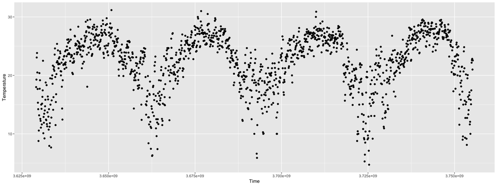

```r
ggplot2::ggplot(dfTemperatureData) + ggplot2::geom_point( ggplot2::aes( x = Time, y = Temperature ) )
```

# Quantile Regression workflow: first example

Here is a Quantile Regression (QR) workflow specification:

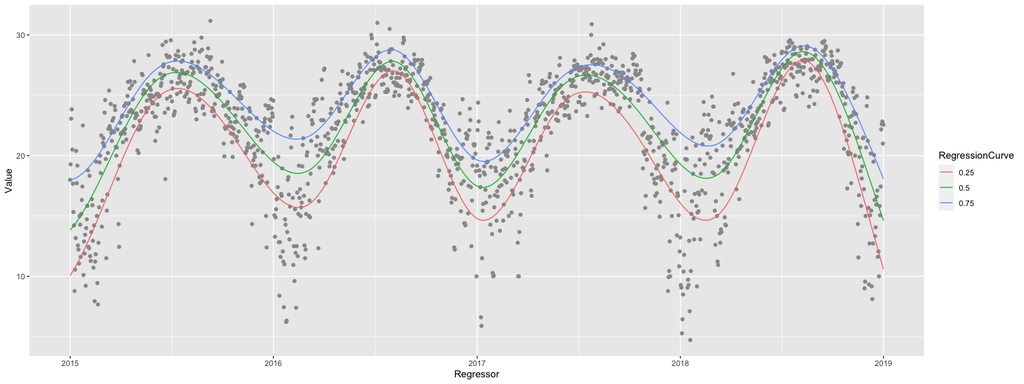

```r
qrmon2 <-
  eval( expr = to_QRMon_R_command(
    "create from dfTemperatureData;
     compute quantile regression with 12 knots and probabilities 0.25, 0.5, and 0.75;
     show date list plot with date origin 1900-01-01;", parse = TRUE) )
```

# How it is done?

For a given ML domain (like QR or LSA) we create two types of Domain Specific Languages (DSL’s):

1. a software monad (i.e. programming language pipeline package) and
2. a DSL that is a subset of a spoken language.

These two DSL’s are combined: the latter translates natural language commands into the former.

By executing those translations we interpret commands of spoken DSL’s into ML computational results.

Note, that we assume that there is a separate system that converts speech into text.

# Development cycle

Here is a clarification diagram:

[figure not shown]

MonadicMakingOfMLConversationalAgents

# Grammars and parsers

For each type of workflow is developed a specialized DSL translation [Raku](https://raku.org) module.

Each Raku module:

1. Has grammars for parsing a sequence of natural commands of a certain DSL
2. Translates the parsing results into corresponding software monad code

Different programming languages and packages can be the targets of the DSL translation.

(At this point are implemented DSL-translators to Python, R, and Wolfram Language.)

Here is an [example grammar](https://github.com/antononcube/ConversationalAgents/blob/master/Packages/Perl6/QuantileRegressionWorkflows/lib/QuantileRegressionWorkflows/Grammar.pm6).

# Quantile Regression workflow: translation

Here is how a sequence of natural commands that specifies a QR workflow is translated into code for a QR software monad:

```r
qrExpr <-
  to_QRMon_R_command(
    "create from dfTemperatureData;
     compute quantile regression with knots 12 and probabilities 0.05, 0.95;
     find outliers;", parse = FALSE )
qrExpr
```

```
## [1] "QRMonUnit( data = dfTemperatureData) %>%"                            "QRMonQuantileRegression(df = 12, probabilities = c(0.05, 0.95)) %>%"
## [3] "QRMonOutliers() %>% QRMonOutliersPlot()"
```

# Quantile Regression workflow: evaluation

Here we evaluate the generated QR monad code:

```r
qrmon2 <- eval(expr = parse( text = paste(qrExpr)))
```

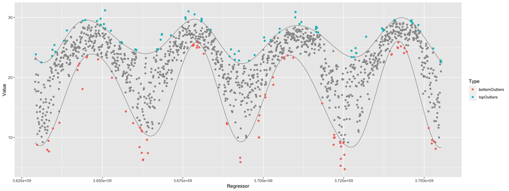

# Latent Semantic Analysis workflow: translation

Here is how a sequence of natural commands that specifies a LSA workflow is translated into code for a LSA software monad:

```r
lsaExpr <-
  to_LSAMon_R_command(
    "create from textHamlet;
     make document term matrix with automatic stop words and without stemming;
     apply lsi functions global weight function idf, local term weight function none, normalizer function cosine;
     extract 12 topics using method SVD, max steps 120, and min number of documents per term 2;
     show thesaurus table for ghost and grave;", parse = FALSE  )
lsaExpr
```

```
## [1] "LSAMonUnit(textHamlet) %>%"
## [2] "LSAMonMakeDocumentTermMatrix( stopWords = NULL, stemWordsQ = FALSE) %>%"
## [3] "LSAMonApplyTermWeightFunctions(globalWeightFunction = \"IDF\", localWeightFunction = \"None\", normalizerFunction = \"Cosine\") %>%"
## [4] "LSAMonExtractTopics( numberOfTopics = 12, method = \"SVD\",  maxSteps = 120, minNumberOfDocumentsPerTerm = 2) %>%"
## [5] "LSAMonEchoStatisticalThesaurus( words = c(\"ghost\", \"grave\"))"
```

# Latent Semantic Analysis workflow: evaluation

Here we execute the generated LSA monad code:

```r
lsamon2 <- eval(expr = parse( text = paste(lsaExpr)))
```

```
##    SearchTerm Word.Distance Word.Index Word.Word
## 1       ghost  0.0000000000        623     ghost
## 2       ghost  2.7115975105         27     again
## 3       ghost  3.0337860674        513    father
## 4       ghost  3.1751511099       1465     stage
## 5       ghost  3.2288933788       1644     under
## 6       ghost  3.2397578292        319     cries
## 7       ghost  3.3836383544       1312         s
## 8       ghost  3.4981754944       1512     swear
## 9       ghost  3.5206941757        935       mar
## 10      ghost  3.5872178308        744       hor
## 11      ghost  3.5874041920       1550      thee
## 12      ghost  3.5910108214       1587       thy
## 13      grave  0.0000000000        648     grave
## 14      grave  0.0002148722         60       any
## 15      grave  0.0002240588       1597    tongue
## 16      grave  0.0002393262        151    better
## 17      grave  0.0002512303        741    honour
## 18      grave  0.0002984727       1317      said
## 19      grave  0.0003411081       1419     sleep
## 20      grave  0.0003546082        897      long
## 21      grave  0.0003742935       1251    reason
## 22      grave  0.0004033964       1362      sent
## 23      grave  0.0004205840       1735     while
## 24      grave  0.0004235261       1288      ring
```

# Recommender workflow: data

Consider the making of a recommender over the Titanic data:

```r
dfTitanic[sample(1:nrow(dfTitanic), 12), ]
```

```
##           id passengerClass passengerAge passengerSex passengerSurvival
## 825   id.825            3rd           40         male              died
## 439   id.439            2nd           20       female          survived
## 98     id.98            1st           30       female          survived
## 726   id.726            3rd           20       female          survived
## 650   id.650            3rd           20         male              died
## 1141 id.1141            3rd           20         male              died
## 418   id.418            2nd           30         male              died
## 795   id.795            3rd            0       female          survived
## 616   id.616            3rd           20         male              died
## 496   id.496            2nd           -1         male              died
## 822   id.822            3rd           30         male              died
## 448   id.448            2nd           20         male              died
```

```r
summary(as.data.frame(unclass(dfTitanic), stringsAsFactors = TRUE))
```

```
##        id       passengerClass  passengerAge   passengerSex passengerSurvival
##  id.1   :   1   1st:323        Min.   :-1.00   female:466   died    :809
##  id.10  :   1   2nd:277        1st Qu.:10.00   male  :843   survived:500
##  id.100 :   1   3rd:709        Median :20.00
##  id.1000:   1                  Mean   :23.55
##  id.1001:   1                  3rd Qu.:40.00
##  id.1002:   1                  Max.   :80.00
##  (Other):1303
```

# Recommender workflow

Here are recommender workflow specification and evaluation results:

```r
smrmon2 <-
  eval( expr = to_SMRMon_R_command(
    "create from dfTitanic;
     apply the LSI functions inverse document frequency, term frequency, and cosine;
     compute the top 6 recommendations for the profile female=1, 30=1;
     extend recommendations with dfTitanic;
     show pipeline value", parse = TRUE ) )
```

```
##   Score Index      id passengerClass passengerAge passengerSex passengerSurvival
## 1     2     1    id.1            1st           30       female          survived
## 2     2    33 id.1027            3rd           30       female          survived
## 3     2    68 id.1059            3rd           30       female              died
## 4     2    72 id.1062            3rd           30       female          survived
## 5     2    99 id.1087            3rd           30       female              died
## 6     2   108 id.1095            3rd           30       female          survived
```

# Handling misspellings

The approach taken in the design and implementation of the natural language commands interpreters can handle misspellings:

```r
smrmon2 <-
  eval( expr = to_SMRMon_R_command(
    "create from dfTitanic;
     aply the LSI functions inverse document frequency, term frequency, and cosine;
     compute the top 6 recomendations for the profle female=1, 30=1;
     extend recommendations with dfTitanic;
     show pipeline value" ) )
```

```
## [1] "Possible misspelling of 'apply' as 'aply'."                     "Possible misspelling of 'recommendations' as 'recomendations'."
## [3] "Possible misspelling of 'profile' as 'profle'."
##   Score Index      id passengerClass passengerAge passengerSex passengerSurvival
## 1     2     1    id.1            1st           30       female          survived
## 2     2    33 id.1027            3rd           30       female          survived
## 3     2    68 id.1059            3rd           30       female              died
## 4     2    72 id.1062            3rd           30       female          survived
## 5     2    99 id.1087            3rd           30       female              died
## 6     2   108 id.1095            3rd           30       female          survived
```

# Not just ML workflows

Obviously this approach can be used for any type of computational workflows.

Here is an example of an Epidemiology Modeling workflow:

```r
ecmCommands <-
'create with the model susceptible exposed infected two hospitalized recovered;
 assign 100000 to the susceptible population;
 set infected normally symptomatic population to be 0;
 set infected severely symptomatic population to be 1;
 assign 0.56 to contact rate of infected normally symptomatic population;
 assign 0.58 to contact rate of infected severely symptomatic population;
 assign 0.1 to contact rate of the hospitalized population;
 simulate for 240 days;
 plot populations results;'
```

```r
to_ECMMon_R_command(ecmCommands, parse = TRUE)
```

```
## expression(ECMMonUnit(model = SEI2HRModel()) %>% ECMMonAssignInitialConditions(initConds = c(SPt = 1e+05)) %>%
##     ECMMonAssignInitialConditions(initConds = c(INSPt = 0)) %>%
##     ECMMonAssignInitialConditions(initConds = c(ISSPt = 1)) %>%
##     ECMMonAssignRateValues(rateValues = c(contactRateINSP = 0.56)) %>%
##     ECMMonAssignRateValues(rateValues = c(contactRateISSP = 0.58)) %>%
##     ECMMonAssignRateValues(rateValues = c(contactRateHP = 0.1)) %>%
##     ECMMonSimulate(maxTime = 240) %>% ECMMonPlotSolutions(stocksSpec = ".*Population"))
```

```r
ecmmon2 <- eval( to_ECMMon_R_command(ecmCommands) )
```

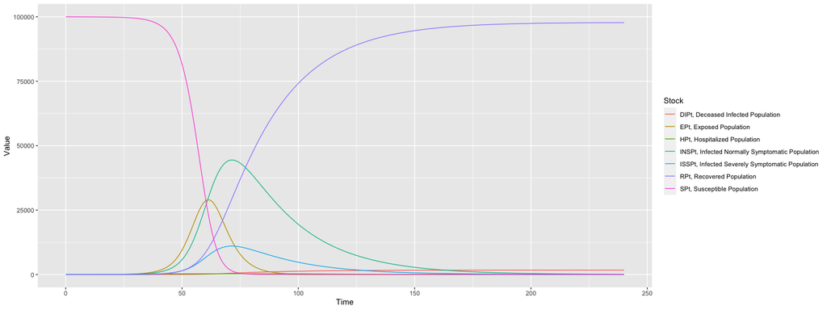

# References

### Repositories

[AAr1] Anton Antonov, R-packages, (2019), GitHub.

[AAr2] Anton Antonov, [Conversational Agents](https://github.com/antononcube/ConversationalAgents), (2017), GitHub.

### Packages

[AAp1] Anton Antonov, [Quantle Regression Monad in R](https://github.com/antononcube/QRMon-R), (2019), GitHub.

[AAp2] Anton Antonov, [Latent Semantic Analysis Monad in R](https://github.com/antononcube/R-packages/tree/master/LSAMon-R), (2019), [R-packages at GitHub](https://github.com/antononcube/R-packages).

[AAp3] Anton Antonov, [Sparse Matrix Recommender Monad in R](https://github.com/antononcube/R-packages/tree/master/SMRMon-R), (2019), [R-packages at GitHub](https://github.com/antononcube/R-packages).

[AAp4] Anton Antonov, [Epidemiology Compartmental Modeling Monad in R](https://github.com/antononcube/ECMMon-R), (2020), GitHub.